# A toy problem: implement training a Support Vector Machine with SGD

Antonio G. Quintela

## SVM

Support Vectors Machines are generalizations of linear decision boundaries for linearly nonseparable cases. It is an optimization based algorithm based on the idea of soft constraint optimization in which nondesirable decisions are penalized following a cost function. Depending on the loss function, the optimization problem could be a convex optimization problem. That convex optimization problems are highly interesting for machine learning because of simplicity and the quantity of possiblities we have to optimize it.

The case of the SVM we have a linear model that we can define as:

$$f(x) = x^Tw + w_0$$

and we can do predictions in the binary classification by applying $sign$ function,

$$y_{pred} = sign(x^Tw + w_0)$$

The margin can be defined as $m(w) = y\cdot (x^Tw + w_0)$. If $m > 0$ it is the margin safety by which f(x) is correct. If $m < 0$ then $m$ is a measure of the margin by which f(x) is wrong.

The problem could be defined in the form,

$$w = \underset{w}{\mathrm{argmin}} \quad \mathbb{L}(w)$$

The part of the cost it could be composed for different terms. The term represented the loss and a term to penalize high weight parameters, called regularization. The term of the cost can be descomposed by the samples allowing us to apply SGD.

$$ \mathbb{L}(w) = \sum_{i=0}^{n\_samp}\ell(m_t(w)) + \frac{\lambda}{2} \| w \|^2$$

We could say that this optimization problem is a SVM when $\ell(m_t(w))$ is a Hinge loss function.

## Hinge Loss

Hinge loss is the function used to define the margin optimization.

$${\displaystyle \ell(y) = \max(0, 1-y_{pred} \cdot y)}$$

## Stochastic Gradient Descent

Stochastic Gradient Descent or SGD for short is an iterative Gradient Descent in which it is used some parts of the sample to optimize locally using the gradient of the curve in a given point of the parameter space trying to find the maxima or the minima.

$${\displaystyle w:=w-\eta \nabla L_{i}(w)}$$

in which $\eta$ is the learning rate.

### Imports

```python
import numpy as np
import matplotlib.pyplot as plt
```

### SVM code file

> > svm.py

> ```
> import numpy as np
> import time
>
>
> class SVM(object):
>     """SVM with SGD optimizer.
>     """
>     def __init__(self, loss='Hinge', batch_size=10, n_epochs=0, learning_rate=0.0001,
>                  stop_step=.000001, lambda_par=1., verbose=False, history=True):
>
>         ## Setting loss
>         loss_functions = {'hinge': Hinge}
>         if type(loss) == str:
>             self.lossf = loss_functions[loss.lower()]()
>         else:
>             self.lossf = loss
>
>         ## Optimizer parameters
>         self.optimizer = 'SGD'
>         self.n_epochs = n_epochs
>         self.batch_size = batch_size
>         self.learning_rate = learning_rate
>         self.stop_step = stop_step
>
>         ## Model parameters
>         self._reset_model()
>         self.lambda_par = lambda_par
>
>         ## Tracking results
>         self.last_loss = 1e16
>         self.change_loss = 1e16
>         self.history = history
>         self._reset_history()
>
>     def predict(self, X):
>         return np.dot(X, self.w)+self.w0
>
>     def score(self, X, y):
>         """Scoring with accuracy measure by default."""
>         y_pred = self.predict(X)
>         return accuracy(y_pred, y)
>
>     def compute_epoch_measures(self, X_train, y_train, X_test, y_test):
>         N_samples = len(X_train)
>         testing_phase = (X_test is not None) and (y_test is not None)
>         if not testing_phase:
>             loss_test = None
>             acc_test = None
>
>         # Prediction train
>         y_p_train = self.predict(X_train)
>
>         # Hinge loss train
>         reg_term = self._regularization()
>         lossf_term = self.lossf.loss(y_p_train, y_train)
>         losses_epoch = reg_term+lossf_term
>
>         # Change loss
>         self.change_loss = self.last_loss-losses_epoch
>         self.last_loss = losses_epoch
>
>         # Accuracy train
>         train_acc = accuracy(np.sign(y_p_train), y_train)
>
>         if testing_phase:
>             # Prediction test
>             y_p_test = self.predict(X_test)
>             # Hinge loss test
>             loss_test = self.lossf.loss(y_p_test, y_test)
>             loss_test += reg_term
>             #Accuracy test
>             acc_test = accuracy(np.sign(y_p_test), y_test)
>
>         # Add to history
>         self._add_epoch_to_history(losses_epoch, train_acc,
>                                    loss_test, acc_test)
>         # Add new epoch to the counter
>         self.epoch_learned += 1
>
>     def fit(self, X_train, y_train, X_test=None, y_test=None):
>         """"""
>         # Setting administrative parameters
>         self._reset_history()
>         t0 = time.time()
>         # Setting general paramaters
>         N_samples, n_feats = X_train.shape
>         # Initialize model parameters
>         self._initialization_weights(n_feats)
>         # Setting loop epochs
>         keep = True
>         i = 0
>         while keep:
>             # Shuffling data
>             data, labels = permut_data(X_train, y_train)
>             # Loop over batches
>             for x_batch, y_batch in self._batch_generator(data, labels):
>                 # Batch prediction
>                 y_batch_pred = self.predict(x_batch)
>                 # Compute gradient
>                 gradloss_w, gradloss_w0 =\
>                     self.lossf.gradient_loss(y_batch_pred, y_batch, x_batch)
>                 gradloss_w += self.lambda_par*self.w
>                 gradloss_w0 += self.lambda_par*self.w0
>                 # Paramters update
>                 self.w -= self.learning_rate*gradloss_w
>                 self.w0 -= self.learning_rate*gradloss_w0
>                 grad_w_reg, grad_w0_reg = self._gradient_regularization()
>                 gradloss_w += grad_w_reg
>                 gradloss_w0 += grad_w0_reg
>             # Tracking loss
>             self.compute_epoch_measures(X_train, y_train, X_test, y_test)
>
>             # Tracking loop
>             i += 1
>             keep = stop_condition(self.change_loss, i, self.n_epochs, self.stop_step)
>         self.fit_times = time.time()-t0
>         return self
>
>     def report_results(self):
>         report = "="*25+"\n"
>         report += "learning_rate = {}\n"
>         report += "regularization = {:.2f}\n"
>         report += "batch_size = {}\n"
>         report += "="*25+"\n"
>         report += "time expended: {:.2f}s\n"
>         report += "num. epochs: {}\n"
>         report += "best epoch acc: {}\n"
>         report += "accuracy train: {:.4f}\n"
>         report += "accuracy test: {:.4f}\n"
>         report += "="*25+"\n"
>         # The criteria of get the accuracy will be the accuracies in the epoch with
>         # better test accuracy.
>         best_i = np.argmax(self.test_accuracy_history)
>         train_accuracy = self.train_accuracy_history[best_i]
>         test_accuracy = self.test_accuracy_history[best_i]
>         report = report.format(self.learning_rate, self.lambda_par, self.batch_size,
>                                self.fit_time, self.epoch_learned, best_i,
>                                train_accuracy, test_accuracy)
>         print(report)
>
>     def _add_epoch_to_history(self, train_loss, train_accuracy,
>                               test_loss=None, test_accuracy=None):
>         if self.history:
>             self.train_loss_history.append(train_loss)
>             self.train_accuracy_history.append(train_accuracy)
>             if test_loss is not None:
>                 self.test_loss_history.append(test_loss)
>                 self.test_accuracy_history.append(test_accuracy)
>
>     def _reset_history(self):
>         self.epoch_learned = 0
>         self.fit_time = 0.
>         self.train_loss_history = None
>         self.test_loss_history = None
>         self.train_accuracy_history = None
>         self.test_accuracy_history = None
>         if self.history:
>             self.train_loss_history = []
>             self.train_accuracy_history = []
>             self.test_loss_history = []
>             self.test_accuracy_history = []
>
>     def _reset_model(self):
>         self.w = None
>         self.w0 = None
>
>     def _initialization_weights(self, n_feats, init_type='gauss'):
>         if init_type == 'zeros':
>             self.w0 = 0.
>             self.w = np.zeros(n_feats)
>         elif init_type == 'gauss':
>             self.w0 = np.random.randn()
>             self.w = np.random.randn(n_feats)
>
>     def _batch_generator(self, data, labels):
>         """We can implement here different options to sample batches."""
>         N_samples = len(data)
>         for init, endit in batch_size_iter(N_samples, self.batch_size):
>             x_batch = data[init:endit]
>             y_batch = labels[init:endit]
>             yield x_batch, y_batch
>
>     def _regularization(self):
>         """By default it is coded 'L2' but it could be implemented others."""
>         return 0.5*(np.dot(self.w, self.w)+self.w0**2)*self.lambda_par
>
>     def _gradient_regularization(self):
>         return self.lambda_par*self.w, self.lambda_par*self.w0
>
>
> class LossFunction(object):
>     """General object for loss functions."""
>     def __init__(self):
>         required_functions = ['loss', 'gradient_loss']
>         for req in required_functions:
>             assert(req in dir(self))
>
>
> class Hinge(LossFunction):
>     """Loss function for trainning binary linear classifiers with target
>     {-1, 1}. It computes the aggregated loss, not the average per sample.
>     """
>
>     def __init__(self, threshold=1.0):
>         self.threshold = threshold
>         super(Hinge, self).__init__()
>
>     def loss(self, y_pred, y_true):
>         z = y_pred * y_true
>         loss = np.mean((self.threshold - z)*(z <= self.threshold).astype(float))
>         return loss
>
>     def gradient_loss(self, y_pred, y, x):
>         """Derivation dL/dw. It is separated the output for w and w0.
>         """
>         z = y_pred * y
>         in_margin = (z <= self.threshold).astype(float)
>
>         gradloss_w = -np.dot(y*in_margin, x)
>         gradloss_w0 = -np.sum(y*in_margin)
>
>         return gradloss_w, gradloss_w0
>
>
> def accuracy(y_pred, y_true):
>     return np.sum(y_true == y_pred) / float(y_true.shape[0])
>
>
> def batch_size_iter(data_size, batch_size):
>     init = 0
>     keep = True
>     while keep:
>         endit = init+batch_size
>         if endit >= data_size:
>             endit = data_size
>             keep = False
>         yield init, endit
>         init += batch_size
>
>
> def stop_condition(loss_change, i, N, stop_step):
>     if N != 0:
>         if i >= N:
>             return False
>     if loss_change < stop_step:
>         return False
>     return True
>
>
> def permut_data(data, labels=None):
>     n_samples = len(data)
>     reindices = np.random.permutation(n_samples)
>     if labels is None:
>         return data[reindices]
>     else:
>         return data[reindices], labels[reindices]
> ```

```python
from svm import SVM
```

### Test code file

> > `tests.py`

> ```
> import numpy as np
> import unittest
> from itertools import product
>
> from svm import *
>
>
> class PermutationDataTest(unittest.TestCase):
>
>     def testpropershape(self):
>         data = np.random.random((10, 4))
>         labels = np.random.randint(0, 2, 10)*2-1
>
>         data_per = permut_data(data)
>         self.assertEqual(data_per.shape, data.shape)
>
>         data_per, labels_per = permut_data(data, labels)
>         self.assertEqual(data_per.shape, data.shape)
>         self.assertEqual(labels_per.shape, labels.shape)
>
>
> class StopperTest(unittest.TestCase):
>
>     def test_stopbychange(self):
>         N = 0
>         i = 10
>         loss_change = 0.5
>
>         stop_step = 0.4
>         ifkeep = stop_condition(loss_change, i, N, stop_step)
>         self.assertTrue(ifkeep)
>
>         stop_step = 0.6
>         ifkeep = stop_condition(loss_change, i, N, stop_step)
>         self.assertFalse(ifkeep)
>
>     def test_stopbyiter(self):
>         loss_change = 0.5
>         stop_step = 0.4
>         N = 100
>
>         i = 10
>         ifkeep = stop_condition(loss_change, i, N, stop_step)
>         self.assertTrue(ifkeep)
>
>         i = 100
>         ifkeep = stop_condition(loss_change, i, N, stop_step)
>         self.assertFalse(ifkeep)
>
>
> class BatchCreatorTest(unittest.TestCase):
>
>     def test_run_batch_iterator(self):
>         data_size = 100
>         batch_size = 9
>         for init, endit in batch_size_iter(data_size, batch_size):
>             self.assertTrue(init != endit)
>             self.assertTrue(init < endit)
>         self.assertEqual(endit, data_size)
>
>         data_size = 100
>         batch_size = 10
>         for init, endit in batch_size_iter(data_size, batch_size):
>             self.assertTrue(init != endit)
>             self.assertTrue(init < endit)
>         self.assertEqual(endit, data_size)
>
>
> class AccuracyFunctionTest(unittest.TestCase):
>
>     def test_order_independency(self):
>         n = 10
>         n_tests = 20
>
>         for i in range(n_tests):
>             y0 = np.random.randint(0, 2, n)
>             y1 = np.random.randint(0, 2, n)
>             reindices = np.random.permutation(n)
>             self.assertEqual((accuracy(y0, y1), accuracy(y0[reindices], y1[reindices]))
>
>     def test_symetry(self):
>         n = 10
>         n_tests = 20
>
>         for i in range(n_tests):
>             y0 = np.random.randint(0, 2, n)
>             y1 = np.random.randint(0, 2, n)
>             self.assertEqual((accuracy(y0, y1), accuracy(y1, y0))
>
>
> class HingeLossTest(unittest.TestCase):
>
>     def _generator_labels(self, n):
>         return np.random.randint(0, 2, n)*2-1
>
>     def test_loss(self):
>         n = 20
>         y0 = np.random.random(n)*2-1
>         y1 = self._generator_labels(n)
>
>         thresholds = [0, 1, 2]
>         for thr in thresholds:
>             lossf = Hinge(thr)
>             lossf.loss(y0, y1)
>
>     def test_gradient(self):
>         n, n_feats = 20, 10
>         y0 = np.random.random(n)*2-1
>         y1 = self._generator_labels(n)
>         x = np.random.random((n, n_feats))
>
>         thresholds = [0, 1, 2]
>         for thr in thresholds:
>             lossf = Hinge(thr)
>             grad_w, grad_w0 = lossf.gradient_loss(y0, y1, x)
>             self.assertEqual((len(grad_w), n_feats)
>
> class SVMTest(unittest.TestCase):
>
>     def _instantiator(self):
>         loss=['Hinge', Hinge()]
>         batch_size=[10]
>         n_epochs=[0, 100]
>         learning_rate=[0.0001, 1.]
>         stop_step=[.000001, 100]
>         lambda_par=[0.01, 1., 10.]
>         verbose=[True, False]
>         history=[True, False]
>         possibilities = [loss, batch_size, n_epochs, learning_rate, stop_step,
>                          lambda_par, verbose, history]
>         for p in product(*possibilities):
>             model = SVM(*p)
>             yield p, model
>
>     def test_initialization(self):
>         n, n_feats = 100, 20
>         data = np.random.random((n, n_feats))
>         labels = np.random.randint(0, 2, n)*2-1
>
>         for p, model in self._instantiator():
>             ## General asserts
>             self.assertEqual(model.optimizer, 'SGD')
>             self.assertEqual(model.batch_size, p[1])
>             self.assertEqual(model.n_epochs, p[2])
>             self.assertEqual(model.stop_step, p[4])
>             self.assertEqual(model.lambda_par, p[5])
>             self.assertIsNone(model.w)
>             self.assertIsNone(model.w0)
>
>             ## Special cases
>             if not p[7]:
>                 self.assertIsNone(model.train_loss_history)
>                 self.assertIsNone(model.test_loss_history)
>                 self.assertIsNone(model.train_accuracy_history)
>                 self.assertIsNone(model.test_accuracy_history)
>
>             ## Weights initialization
>             model._initialization_weights(n_feats, init_type='gauss')
>             model._reset_model()
>             model._initialization_weights(n_feats, init_type='zeros')
>             model._reset_model()
>             model._reset_history()
>
>             ## Batch creation testing
>             for x_batch, y_batch in model._batch_generator(data, labels):
>                 self.assertTrue(len(x_batch) >= p[1])
>
>             ## Computer functions
>             if p[7]:
>                 model._initialization_weights(n_feats, init_type='gauss')
>                 model.compute_epoch_measures(data, labels, None, None)
>                 model.compute_epoch_measures(data, labels, data, labels)
>
>     def test_fitmodel(self):
>         n, n_feats = 100, 5
>         data = np.random.random((n, n_feats))
>         labels = np.random.randint(0, 2, n)*2-1
>
>         for p, model in self._instantiator():
>             model.n_epochs = 100
>             model.fit(data, labels)
>             model.fit(data, labels, data, labels)
>             model.predict(data)
>             model.score(data, labels)
>             if p[7]:
>                 self.assertEqual(model.epoch_learned, len(model.train_loss_history))
>                 self.assertEqual(model.epoch_learned, len(model.train_accuracy_history))
>                 self.assertEqual(model.epoch_learned, len(model.test_loss_history))
>                 self.assertEqual(model.epoch_learned, len(model.test_accuracy_history))
>
>
> if __name__ == '__main__':
>     unittest.main()
> ```

```python
## Apply test to the code
%run tests.py
```

```
..........
----------------------------------------------------------------------
Ran 10 tests in 5.841s

OK
```

### Load data

```python
data = np.loadtxt('data/features.txt', delimiter=',')
target = np.loadtxt('data/target.txt', delimiter=',')
```

### Function definitions

```python
def weights_histogram(model):
    title = r'Histogram of the distribution of weight values '
    title += r'($\eta=0.0001$, $\lambda=1.$, $b_s={}$)'.format(model.batch_size)
    fig = plt.figure(figsize=(10, 5))
    _ = plt.hist(model.w, bins=20)
    _ = plt.title(title)
    _ = plt.xlabel('weights')
    _ = plt.ylabel('Counts')
```

```python
def losses_accross_training(model):
    title = r'Loss through epochs of SGD '
    title += r'($\eta=0.0001$, $\lambda=1.$, $b_s={}$)'.format(model.batch_size)
    fig = plt.figure(figsize=(14, 6))
    plt.xlim([0, len(model.train_loss_history)])
    _ = plt.plot(model.train_loss_history, 'b--', label='train_loss')
    _ = plt.plot(model.test_loss_history, 'r-', label='test_loss')
    _ = plt.title(title)
    _ = plt.xlabel("epochs")
    _ = plt.ylabel("Loss")
    legend = plt.legend(loc='upper right')
```

```python
def acc_accross_training(model):
    title = r'Accuracy through epochs of SGD '
    title += r'($\eta=0.0001$, $\lambda=1.$, $b_s={}$)'.format(model.batch_size)
    fig = plt.figure(figsize=(14, 6))
    plt.xlim([0, len(model.train_accuracy_history)])
    _ = plt.plot(model.train_accuracy_history, 'b--', label='train_loss')
    _ = plt.plot(model.test_accuracy_history, 'r-', label='test_loss')
    _ = plt.title(title)
    _ = plt.xlabel("epochs")
    _ = plt.ylabel("Accuracy")
    legend = plt.legend(loc='lower right')
```

## Study with batch_size=1

```python
model = SVM(n_epochs=1000, batch_size=1, learning_rate=0.0001)
model = model.fit(data[:-1000], target[:-1000], data[-1000:], target[-1000:])
```

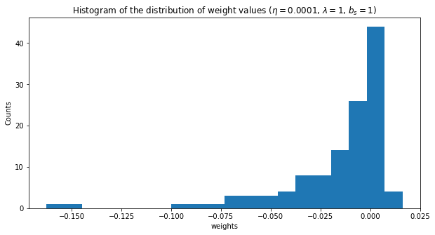

```python
weights_histogram(model)
```

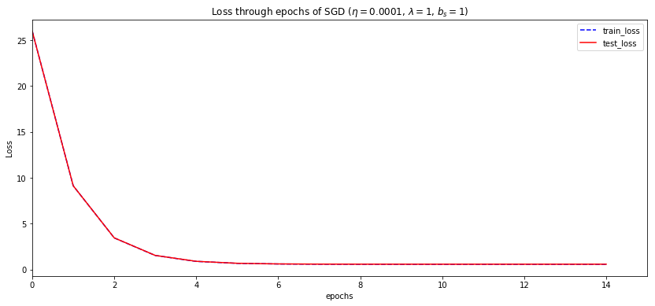

```python
losses_accross_training(model)
```

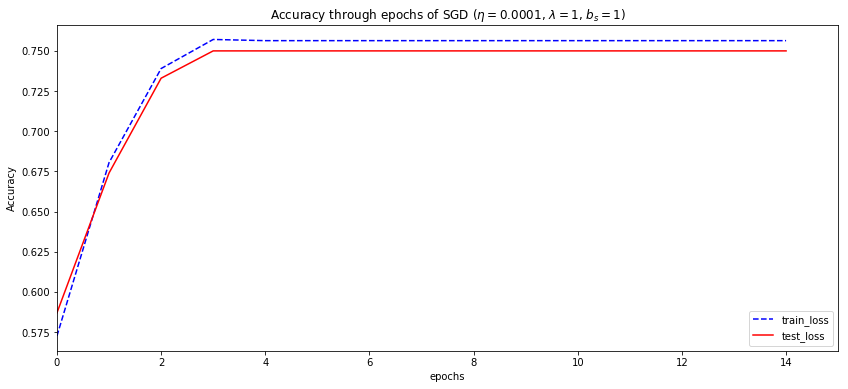

```python
acc_accross_training(model)
```

```python
model.report_results()
```

```
=========================
learning_rate = 0.0001
regularization = 1.00
batch_size = 1
=========================
time expended: 0.00s
num. epochs: 15
best epoch acc: 3
accuracy train: 0.7571
accuracy test: 0.7500
=========================
```

## Study with batch_size=10

```python
model = SVM(n_epochs=1000, batch_size=10, learning_rate=0.0001)
model = model.fit(data[:-1000], target[:-1000], data[-1000:], target[-1000:])
```

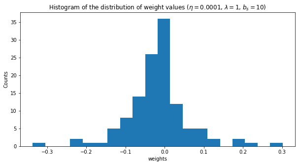

```python
weights_histogram(model)
```

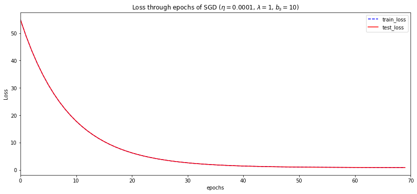

```python
losses_accross_training(model)
```

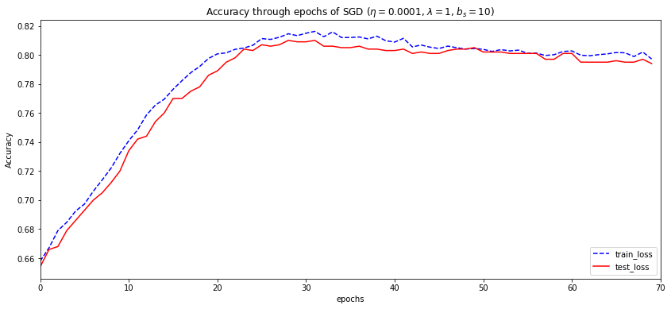

```python
acc_accross_training(model)
```

```python
model.report_results()
```

```
=========================
learning_rate = 0.0001
regularization = 1.00
batch_size = 10
=========================
time expended: 0.00s
num. epochs: 70
best epoch acc: 28
accuracy train: 0.8146
accuracy test: 0.8100
=========================
```

## Study with batch_size=100

```python
model = SVM(n_epochs=1000, batch_size=100, learning_rate=0.0001)
model = model.fit(data[:-1000], target[:-1000], data[-1000:], target[-1000:])
```

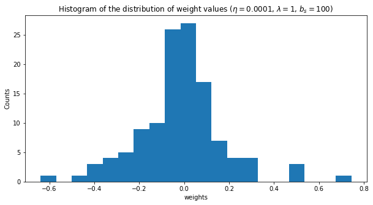

```python
weights_histogram(model)
```

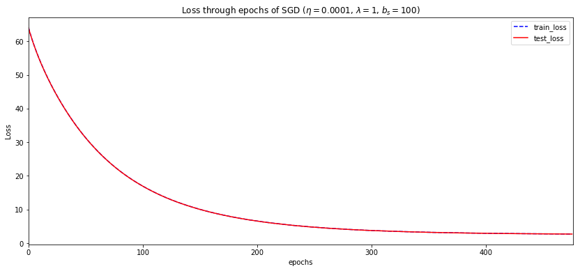

```python
losses_accross_training(model)
```

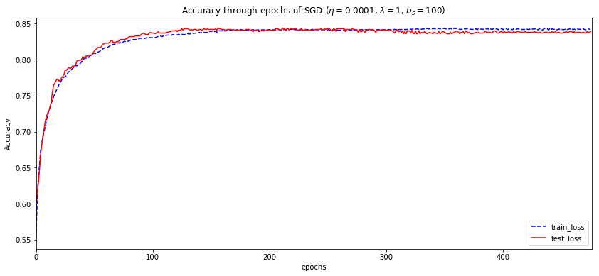

```python
acc_accross_training(model)
```

```python
model.report_results()
```

```
=========================
learning_rate = 0.0001
regularization = 1.00
batch_size = 100
=========================
time expended: 0.00s
num. epochs: 476
best epoch acc: 156
accuracy train: 0.8400
accuracy test: 0.8440
=========================
```

## Comments

The results are self-conclusives. Quicker convergence for smaller batch size but lower accuracy reached. On the other hand, for higher batch_size, you need more epochs to converge but reach higher accuracy.

## Comments about the code

The code has lack of completitude. The design is open to new improvements that are not in the code because of the lack of time and the purpose of that exercise.

There are several improvements over that code design. From control values of the step in order to keep numerical stability (it could be certain regions with huge slope, due to the nonderivative property of Hinge in certain points of the parameter space. Also we can make dynamic learning step in order to skip quickly uninteresting places of the loss landscape and put more effort in exploring the interesting ones.

If we would desire to use different optimizers probably it had been better to keep separated the optimizer and the model.